# time_TM

2022-11-07

## Disclaimer

It was my HW for discourse course in bachelor. I don’t like my code very much but to make analysis as full as I can now, I will add this file into the folder also. It was devoted to topic modelling of the book. I divided the novel into three books manually and made .csv file in google-sheets (well, now I of course can do smth wiser, but still). Preprocessing is done with tidytext and textstem packages, topic modelling – with topicmodels and ldatuning (to find out the optimal number of topics).

Загрузка пакетов и обработка переменной chapter (изначально она numeric, чтобы было удобнее нумеровать главы в таблице во время подготовки данных). Датасет загружали через environment -> Import Dataset -> From Text (readr) -> расположение файла на устройстве.

```r
library(readr)
library(dplyr)
library(ggplot2)
library(tidytext)
library(stopwords)
library(topicmodels)
library(textstem)
library(ldatuning)

Hard_Times = read.csv("C:/Users/yanak/Downloads/Hard_Times.csv")
Hard_Times$Book = as.character(Hard_Times$Book)
```

Лемматизация

```r
tidy_text = Hard_Times %>%
unnest_tokens(word, Text) %>%
anti_join(stop_words)  %>%
mutate(lemma = textstem::lemmatize_words(word))
```

Частотность лемм по книгам

```r
word_counts = tidy_text %>%
count(Book, lemma, sort = TRUE) %>%
ungroup()

word_counts = word_counts %>%
filter(n < quantile(word_counts$n, 0.99))
```

Матрица книга-лемма

```r
times_dtm = word_counts %>% # so, tm is based just on word frequencies
cast_dtm(Book, lemma, n)
```

Определение оптимального количества топиков для моделирования (да, это считается долго…) [Murzintcev, 2020]

```r
topics_num = FindTopicsNumber(
times_dtm,
topics = seq(from = 2, to = 15, by = 1),
metrics = c("Griffiths2004", "CaoJuan2009", "Arun2010", "Deveaud2014"),
method = "Gibbs",
control = list(seed = 77),
mc.cores = 2L,
verbose = TRUE
)
```

```
## fit models... done.
## calculate metrics:
##   Griffiths2004... done.
##   CaoJuan2009... done.
##   Arun2010... done.
##   Deveaud2014... done.
```

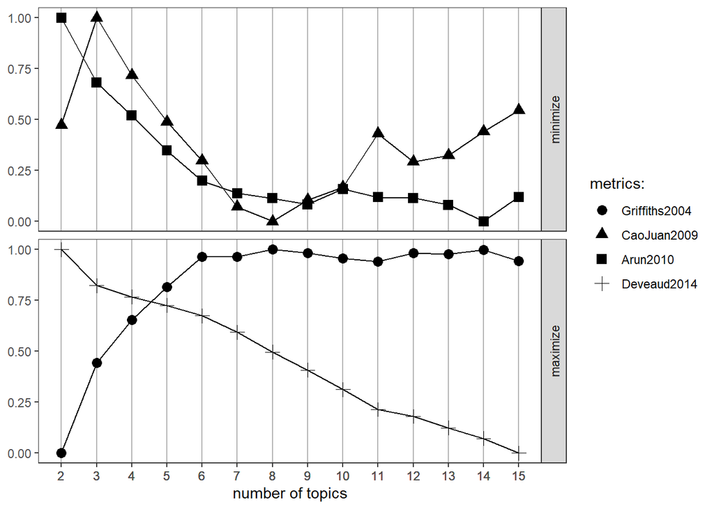

```r
FindTopicsNumber_plot(topics_num)
```

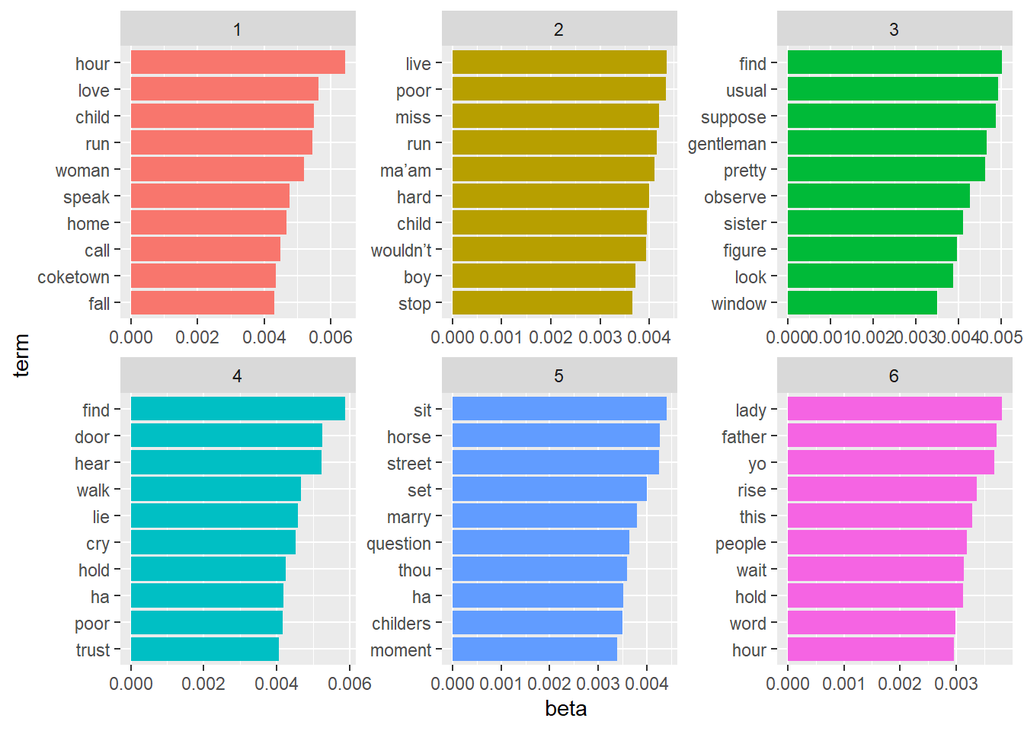

```r
times_lda = LDA(times_dtm, k = 6, control = list(seed = 12345))

times_topics = tidy(times_lda, matrix = "beta")

times_top_terms = times_topics %>%
group_by(topic) %>%
slice_max(beta, n = 10) %>%
ungroup() %>%
arrange(topic, -beta)

times_top_terms %>%
mutate(term = reorder_within(term, beta, topic)) %>%
ggplot(aes(beta, term, fill = factor(topic))) +
geom_col(show.legend = FALSE) +
facet_wrap(~ topic, scales = "free") +
scale_y_reordered()
```

So, topics 1 and 4 belong to Book 1; 2 and 5 - to Book 2 and the last two - to Book 3. Talking about the most frequent words, I can say the follows:

- Book 1 is devoted to the city, where everything takes place (Coketown); peoples’ interaction (lie - trust, speak, call, love); buldings (home, door) and smth diasppointing (cry, poor, lie). I guess run and child are binded (because of Sissy Jupe, who was a child and had huge problems).
- Book 2. There are vernacular forms of words (ha, thou, ma’am) which were used by Stephen Blackpool - one of the main figure at this part of the novel. He couldn’t marry Rachel because he was already married on the disgusting woman. Poor people couldn’t divorce in Victorian England.
- Book 3 tells us about the lady who brought up a son. This son became then gentleman and imagined a story that his mom had left him and he had reached everything by himself. It is a lie, of course, and his mom was waiting everyday near his house, looking at his life, rise and falls. No one knew who is this lady until the end of the book.

Though, I’m not really sure whether I could understand these topics if I didn’t read the book earlier :)